# Image_Classification_Computer_Vision_with_Convolutional_Neural_Networks_and_PyTorch

In this project, we'll have a look at a typical workflow for an image classification problem with a convolutional neural network and PyTorch.

There are four major steps to follow during a machine learning process:

1. Data preparation
2. Model building
3. Model training
4. Model evaluation

And now, without further ado, let's jump right in and start at the first step.

# Data Preparation

Let's import the libraries we're going to need:

```python
import torch
from torch import nn
import torchvision
from torchvision import datasets
from torchvision.transforms import ToTensor
from torch.utils.data import DataLoader
import matplotlib.pyplot as plt
```

As you see, we're importing `torchvision` here. This is the most important PyTorch computer vision library. It contains datasets, models and image transformations that we use to handle vision-related tasks.

We'll also need `torchvision.datasets`, which contains multiple datasets for image classification, object detection, and other computer vision-related problems.

Next, we'll need `torchvision.transforms` to handle image transformations, and in particular `ToTensor` to transform image data into tensors.

Finally, we'll need `torch.utils.data.DataLoader` to create a Python iterable over a dataset.

## The Data

We're going to use the [EuroSAT dataset](https://pytorch.org/vision/main/generated/torchvision.datasets.EuroSAT.html#torchvision.datasets.EuroSAT). It's one of many datasets meant for image classification available in `torchvision.datsets`. You can read about more built-in datasets [here](https://pytorch.org/vision/main/datasets.html).

Here's the [original description](https://github.com/phelber/eurosat) of the dataset:

*In this study, we address the challenge of land use and land cover classification using Sentinel-2 satellite images. The Sentinel-2 satellite images are openly and freely accessible provided in the Earth observation program Copernicus. We present a novel dataset based on Sentinel-2 satellite images covering 13 spectral bands and consisting out of 10 classes with in total 27,000 labeled and geo-referenced images.*

So, let's load the dataset:

```python
data = torchvision.datasets.EuroSAT(
    root="data",
    download=True,
    transform=ToTensor()
)
```

Here we specify the following parameters:

- root - root directory of the dataset
- download - if True, downloads the dataset from the internet (provided it's not downloaded yet) and puts it in root directory
- transform - a function that transforms the data on download and returns a transformed version

Let's split the data into training and test sets.

```python
from sklearn.model_selection import train_test_split
train_data, test_data = train_test_split(data, test_size=0.2, random_state=42)
```

### Viewing the Data

Let's view a sample of the data.

```python
image, label = train_data[0]
image, label
```

```
(tensor([[[0.1412, 0.1412, 0.1333,  ..., 0.1922, 0.1843, 0.1882],
          [0.1412, 0.1412, 0.1333,  ..., 0.1961, 0.1922, 0.2000],
          [0.1569, 0.1529, 0.1373,  ..., 0.2667, 0.2314, 0.2000],
          ...,
          [0.4235, 0.4235, 0.4392,  ..., 0.2392, 0.2549, 0.2824],
          [0.3490, 0.3412, 0.4471,  ..., 0.2392, 0.2706, 0.3216],
          [0.3294, 0.3216, 0.4078,  ..., 0.2392, 0.2902, 0.3529]],

         [[0.2510, 0.2510, 0.2431,  ..., 0.2902, 0.2941, 0.2980],
          [0.2510, 0.2510, 0.2431,  ..., 0.2863, 0.2902, 0.2980],
          [0.2745, 0.2706, 0.2549,  ..., 0.3333, 0.3020, 0.2784],
          ...,
          [0.4745, 0.4745, 0.4902,  ..., 0.3608, 0.3569, 0.3686],
          [0.3922, 0.3961, 0.5020,  ..., 0.3529, 0.3490, 0.3843],
          [0.3725, 0.3765, 0.4627,  ..., 0.3529, 0.3529, 0.4000]],

         [[0.2941, 0.2941, 0.2980,  ..., 0.3176, 0.3098, 0.3137],
          [0.2941, 0.2941, 0.2902,  ..., 0.3176, 0.3098, 0.3176],
          [0.3059, 0.3098, 0.2980,  ..., 0.3725, 0.3412, 0.3137],
          ...,
          [0.4980, 0.4980, 0.5137,  ..., 0.3412, 0.3451, 0.3608],
          [0.4078, 0.4078, 0.5059,  ..., 0.3373, 0.3412, 0.3804],
          [0.3804, 0.3804, 0.4627,  ..., 0.3373, 0.3490, 0.4000]]]),
 5)
```

### Input and Output

The input are the tensors the images were transformed into on download. There are 3 color channels (red, green, blue), the height and width are 64:

```python
image.shape
```

```
torch.Size([3, 64, 64])
```

The output is just a single number representing the class. From the dataset description we know there are 10 classes. Let's enumerate them:

```python
classes = data.classes
classes
```

```
['AnnualCrop',
 'Forest',
 'HerbaceousVegetation',
 'Highway',
 'Industrial',
 'Pasture',
 'PermanentCrop',
 'Residential',
 'River',
 'SeaLake']
```

### Data Visualization

Let's visualize the first sample in the training set:

```
(np.float64(-0.5), np.float64(63.5), np.float64(63.5), np.float64(-0.5))
```

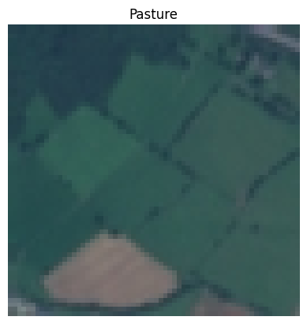

```python
image, label = train_data[0]
plt.imshow(image.permute(1, 2, 0))
plt.title(classes[label])
plt.axis(False)
```

We use the `image.permute` method to change the order of the dimensions. The original order was: color_channel (0) - height (1) - width (2). We need it to be height (1) - width (2) - color_channel (0), hence this specific order.

Now, let's visualize more samples:

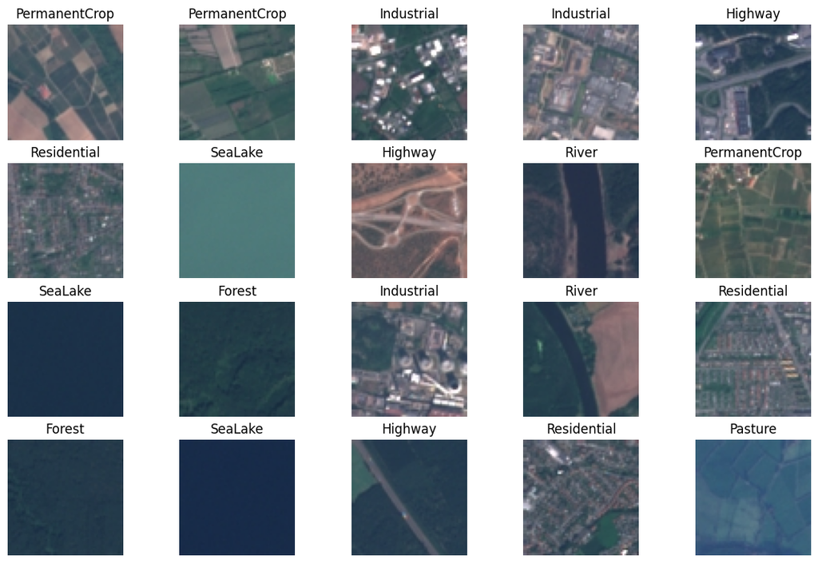

```python
torch.manual_seed(42)
fig = plt.figure(figsize=(14, 9))
rows, cols = 4, 5
for i in range(1, rows * cols + 1):
    random_idx = torch.randint(0, len(train_data), size=[1]).item()
    img, label = train_data[random_idx]
    fig.add_subplot(rows, cols, i)
    plt.imshow(img.permute(1, 2, 0))
    plt.title(classes[label])
    plt.axis(False)
```

## The DataLoader

Let's check out the number of samples in both sets:

```python
len(train_data), len(test_data)
```

```
(21600, 5400)
```

It's a lot of data. It'll be more efficient to break up the large dataset into smaller chunks called batches and work at one batch at a time. To do that, we need a `DataLoader`. Now the model will have an opportunity to improve not every epoch, but every batch, so much more frequently. A good batch size is 32. We'll also shuffle the samples so that if they are in any special order, this order will not impact the process of learning. We don't want the model to learn the order. It's more efficient to leave the data unshuffled in the test set, though:

```python
BATCH_SIZE = 32
train_dataloader = DataLoader(train_data, batch_size=BATCH_SIZE, shuffle=True)
test_dataloader = DataLoader(test_data, batch_size=BATCH_SIZE, shuffle=False)

print(f'Train dataloder: {len(train_dataloader)} batches of {BATCH_SIZE}')
print(f'Test dataloader: {len(test_dataloader)} batches of {BATCH_SIZE}')
```

```
Train dataloder: 675 batches of 32
Test dataloader: 169 batches of 32
```

Let's check out the shape of the data in the training dataloader:

```python
train_features_batch, train_labels_batch = next(iter(train_dataloader))
train_features_batch.shape, train_labels_batch.shape
```

```
(torch.Size([32, 3, 64, 64]), torch.Size([32]))
```

So, we we have one more dimension, the batch size.

# Device-Agnostic Code

Let's set the device to GPU (cuda) if it's available or CPU if it's not:

```python
device = 'cuda' if torch.cuda.is_available() else 'cpu'
device
```

```
'cuda'
```

# Baseline Model

It's always good practice to start with a baseline model other models will be compared to. This way, we'll be able to see how our next models perform - better or worse than the baseline model.

So, the baseine model will contain just three layers: an `nn.Flatten` layer and two `nn.Linear` layers, so no nonlinearity:

```python
class EuroSATModelV0(nn.Module):
    def __init__(self, input_shape: int, hidden_units: int, output_shape: int):
        super().__init__()
        self.layer_stack = nn.Sequential(
            nn.Flatten(),
            nn.Linear(in_features=input_shape, out_features=hidden_units),
            nn.Linear(in_features=hidden_units, out_features=output_shape)
        )

    def forward(self, x):
        return self.layer_stack(x)
```

The `nn.Flatten` layer reduces the dimensions represented by height and width into a single dimension. Let's create an instance of the model:

```python
model0 = EuroSATModelV0(
    input_shape=3 * 64 * 64,
    hidden_units=10,
    output_shape=len(classes)
)
model0.to(device)
```

```
EuroSATModelV0(
  (layer_stack): Sequential(
    (0): Flatten(start_dim=1, end_dim=-1)
    (1): Linear(in_features=12288, out_features=10, bias=True)
    (2): Linear(in_features=10, out_features=10, bias=True)
  )
)
```

## Loss Function, Optimizer, Accuracy

Next, we need a loss function, an optimizer and some evaluation metrics. We'll use `CrossEntropyLoss` as the loss function, `SGD` as the optimizer and `torchmetrics.Accuracy` as the only metric. First, we must make sure `torchmetrics` is installed:

```python
!pip install torchmetrics
```

Now we can instantiate the three:

```python
import torchmetrics

loss_fn = nn.CrossEntropyLoss()
optimizer = torch.optim.SGD(params=model0.parameters(), lr=0.02)
accuracy_fn = torchmetrics.Accuracy(task='multiclass', num_classes=len(classes)).to(device)
```

## Functionizing the Training and Test Loops

As we're going to train and evaluate a couple models, let's make things a little easier for us and functionalize the two loops, the training loop and the test loop:

```python
def train_step(model: nn.Module,
               data_loader: DataLoader,
               loss_fn: nn.Module,
               optimizer: torch.optim.Optimizer,
               accuracy_fn: torchmetrics.Accuracy,
               device: torch.device = device):
    '''
    Trains the model on a data_loader.

    Args:
        model (nn.Module): A PyTorch model to train.
        data_loader (DataLoader): A PyTorch DataLoader instance.
        loss_fn (nn.Module): The loss function of the model.
        optimizer (torch.optim.Optimizer): The optimizer to use to update the model's parameters.
        accuracy_fn (torchmetrics.Accuracy): The accuracy function of the model.
        device (torch.device, optional): The device to train on. Defaults to device.
    '''

    train_loss, train_acc = 0, 0
    model.to(device)
    model.train()
    for batch, (X, y) in enumerate(data_loader):
        # send data to device
        X, y = X.to(device), y.to(device)

        # forward pass
        y_pred = model(X)

        # loss
        loss = loss_fn(y_pred, y)
        train_loss += loss

        # accuracy
        acc = accuracy_fn(y_pred, y)
        train_acc += acc

        # zero grad
        optimizer.zero_grad()

        # backpropagation
        loss.backward()

        # optimizer step
        optimizer.step()

    # loss and accuracy per epoch
    train_loss /= len(data_loader)
    train_acc /= len(data_loader)

    # info
    print(f'Train loss: {train_loss:.5f} | Train acc: {train_acc:.5f}')

def test_step(model: nn.Module,
              data_loader: DataLoader,
              loss_fn: nn.Module,
              accuracy_fn: torchmetrics.Accuracy,
              device: torch.device = device):
    '''
    Evaluates the model on a data_loader.

    Args:
        model (nn.Module): A PyTorch model.
        data_loader (DataLoader): A PyTorch DataLoader instance.
        loss_fn (nn.Module): The loss function of the model.
        accuracy_fn (torchmetrics.Accuracy): The accuracy function of the model.
        device (torch.device, optional): The device.
    '''

    test_loss, test_acc = 0, 0
    model.to(device)
    model.eval()
    with torch.inference_mode():
        for X, y in data_loader:
            # send data to device
            X, y = X.to(device), y.to(device)

            # forward pass
            test_pred = model(X)

            # loss
            test_loss += loss_fn(test_pred, y)

            # accuracy
            test_acc += accuracy_fn(test_pred, y)

        # loss and accuracy
        test_loss /= len(data_loader)
        test_acc /= len(data_loader)

        # info
        print(f'Test loss: {test_loss:.5f} | Test acc: {test_acc:.5f}')
```

Let's now use the functions to train and evaluate the baseline model:

```python
torch.manual_seed(42)

epochs = 20

for epoch in range(epochs):
    print(f'Epoch: {epoch}\n---------')
    train_step(model=model0, data_loader=train_dataloader, loss_fn=loss_fn, optimizer=optimizer, accuracy_fn=accuracy_fn)
    test_step(model=model0, data_loader=test_dataloader, loss_fn=loss_fn, accuracy_fn=accuracy_fn)
```

```
Epoch: 0
---------
Train loss: 1.90438 | Train acc: 0.27403
Test loss: 1.73945 | Test acc: 0.37075
Epoch: 1
---------
Train loss: 1.73678 | Train acc: 0.33690
Test loss: 1.71340 | Test acc: 0.31755
Epoch: 2
---------
Train loss: 1.70461 | Train acc: 0.35361
Test loss: 1.79175 | Test acc: 0.30356
Epoch: 3
---------
Train loss: 1.68641 | Train acc: 0.36264
Test loss: 1.68053 | Test acc: 0.37512
Epoch: 4
---------
Train loss: 1.67662 | Train acc: 0.36759
Test loss: 1.64029 | Test acc: 0.38505
Epoch: 5
---------
Train loss: 1.66598 | Train acc: 0.37278
Test loss: 1.63045 | Test acc: 0.38911
Epoch: 6
---------
Train loss: 1.65819 | Train acc: 0.38083
Test loss: 1.77616 | Test acc: 0.30560
Epoch: 7
---------
Train loss: 1.64496 | Train acc: 0.38731
Test loss: 1.74361 | Test acc: 0.33876
Epoch: 8
---------
Train loss: 1.64172 | Train acc: 0.38532
Test loss: 1.63300 | Test acc: 0.37272
Epoch: 9
---------
Train loss: 1.63537 | Train acc: 0.38954
Test loss: 1.70837 | Test acc: 0.35441
```

[output cut: 25 more lines]

```
---------
Train loss: 1.60241 | Train acc: 0.40333
Test loss: 1.69421 | Test acc: 0.38036
Epoch: 17
---------
Train loss: 1.59711 | Train acc: 0.40356
Test loss: 1.64635 | Test acc: 0.42480
Epoch: 18
---------
Train loss: 1.59209 | Train acc: 0.40657
Test loss: 1.60754 | Test acc: 0.43916
Epoch: 19
---------
Train loss: 1.59512 | Train acc: 0.40370
Test loss: 1.64686 | Test acc: 0.34159
```

As we can see, the loss is decreasing and the accuracy is increasing, which is good. Let's create a function to display these two values so that we ca use it later with the other models too:

```python
torch.manual_seed(42)

def evaluate_model(model: nn.Module,
                   data_loader: DataLoader,
                   loss_fn: nn.Module,
                   accuracy_fn: torchmetrics.Accuracy,
                   device: torch.device):
    '''
    Evaluates the model on a data_loader.

    Args:
        model (nn.Module): A PyTorch model trained to make predictions on the data_loader.
        data_loader (DataLoader): A PyTorch DataLoader instance.
        loss_fn (nn.Module): The loss function of the model.
        accuracy_fn (torchmetrics.Accuracy): The accuracy function of the model.

    Returns:
        Returns a dictionary with the results of model predicting on data_loader.
    '''

    loss, acc = 0, 0
    model.eval()
    with torch.inference_mode():
        for X, y in data_loader:
            # send data to device
            X, y = X.to(device), y.to(device)

            # forward pass
            y_pred = model(X)

            # loss
            loss += loss_fn(y_pred, y)

            # accuracy
            acc += accuracy_fn(y_pred, y)

        # loss and accuracy in batch
        loss /= len(data_loader)
        acc /= len(data_loader)

    return {'model': model.__class__.__name__,
            'loss': loss.item(),
            'accuracy': acc.item()}
```

And now let's use the function to evaluate the baseline model:

```python
model0_evaluation = evaluate_model(model=model0, data_loader=test_dataloader, loss_fn=loss_fn, accuracy_fn=accuracy_fn, device=device)
model0_evaluation
```

```
{'model': 'EuroSATModelV0',
 'loss': 1.6468614339828491,
 'accuracy': 0.3415926992893219}
```

# Model with Nonlinearities

Let's create another model, very much like the baseline model, but this time with some nonlinear activation functions between the layers:

```python
class EuroSATModelV1(nn.Module):
    def __init__(self, input_shape: int, hidden_units: int, output_shape: int):
        super().__init__()
        self.layer_stack = nn.Sequential(
            nn.Flatten(),
            nn.Linear(in_features=input_shape, out_features=hidden_units),
            nn.ReLU(),
            nn.Linear(in_features=hidden_units, out_features=output_shape),
            nn.ReLU()
        )

    def forward(self, x):
        return self.layer_stack(x)
```

Here's an instance of the model:

```python
torch.manual_seed(42)

model1 = EuroSATModelV1(
    input_shape=3 * 64 * 64,
    hidden_units=10,
    output_shape=len(classes)
).to(device)
```

Let's define the loss function, optimizer and accuracy:

```python
loss_fn = nn.CrossEntropyLoss()
optimizer = torch.optim.SGD(params=model1.parameters(), lr=0.02)
accuracy_fn = torchmetrics.Accuracy(task='multiclass', num_classes=len(classes)).to(device)
```

Now we can train and evaluate the model:

```python
epochs = 20

for epoch in range(epochs):
    print(f'Epoch: {epoch}\n---------')
    train_step(model=model1, data_loader=train_dataloader, loss_fn=loss_fn, optimizer=optimizer, accuracy_fn=accuracy_fn)
    test_step(model=model1, data_loader=test_dataloader, loss_fn=loss_fn, accuracy_fn=accuracy_fn)
```

```
Epoch: 0
---------
Train loss: 2.22829 | Train acc: 0.18944
Test loss: 2.19198 | Test acc: 0.19903
Epoch: 1
---------
Train loss: 2.17576 | Train acc: 0.20185
Test loss: 2.17099 | Test acc: 0.20587
Epoch: 2
---------
Train loss: 2.15642 | Train acc: 0.21685
Test loss: 2.16047 | Test acc: 0.22608
Epoch: 3
---------
Train loss: 2.14495 | Train acc: 0.22667
Test loss: 2.15271 | Test acc: 0.22584
Epoch: 4
---------
Train loss: 2.13550 | Train acc: 0.23389
Test loss: 2.13791 | Test acc: 0.22898
Epoch: 5
---------
Train loss: 2.12349 | Train acc: 0.23991
Test loss: 2.12725 | Test acc: 0.23126
Epoch: 6
---------
Train loss: 2.11282 | Train acc: 0.23917
Test loss: 2.12444 | Test acc: 0.24932
Epoch: 7
---------
Train loss: 2.10570 | Train acc: 0.24449
Test loss: 2.12664 | Test acc: 0.22947
Epoch: 8
---------
Train loss: 2.10138 | Train acc: 0.24444
Test loss: 2.10546 | Test acc: 0.24069
Epoch: 9
---------
Train loss: 2.09728 | Train acc: 0.24704
Test loss: 2.10856 | Test acc: 0.26769
```

[output cut: 25 more lines]

```
---------
Train loss: 2.08387 | Train acc: 0.25194
Test loss: 2.09910 | Test acc: 0.26492
Epoch: 17
---------
Train loss: 2.08352 | Train acc: 0.25236
Test loss: 2.08875 | Test acc: 0.25234
Epoch: 18
---------
Train loss: 2.08143 | Train acc: 0.25384
Test loss: 2.09729 | Test acc: 0.26418
Epoch: 19
---------
Train loss: 2.08204 | Train acc: 0.25412
Test loss: 2.08610 | Test acc: 0.25481
```

```python
torch.manual_seed(42)

model1_evaluation = evaluate_model(model=model1, data_loader=test_dataloader, loss_fn=loss_fn, accuracy_fn=accuracy_fn, device=device)
model1_evaluation
```

```
{'model': 'EuroSATModelV1',
 'loss': 2.086103677749634,
 'accuracy': 0.2548076808452606}
```

Let's compare the two models:

```python
import pandas as pd

models_comparison = pd.DataFrame([model0_evaluation, model1_evaluation]).set_index('model')
models_comparison
```

| model | loss | accuracy |
| --- | --- | --- |
| EuroSATModelV0 | 1.646861 | 0.341593 |
| EuroSATModelV1 | 2.086104 | 0.254808 |

Looks like adding the nonlinear activation functions didn't help at all. Just the contrary. What about a type of model that is best suited for working with images? Our third, final, model is going to be a convolutional neural network.

## Convolutional Neural Network (CNN)

Convolutional neural networks are good at finding patterns in visual data. Between the input and output layers they contain blocks with, possibly repeated, convolutional layers, activation layers and pooling layers. And possibly also other types of layers. Let's create another model, this time a CNN, with two such blocks and a classifier:

```python
class EuroSATModelV2(nn.Module):
    def __init__(self, input_shape: int, hidden_units: int, output_shape: int):
        super().__init__()
        self.conv_block_1 = nn.Sequential(
            nn.Conv2d(in_channels=input_shape, out_channels=hidden_units, kernel_size=3, stride=1, padding=1),
            nn.ReLU(),
            nn.Conv2d(in_channels=hidden_units, out_channels=hidden_units, kernel_size=3, stride=1, padding=1),
            nn.ReLU(),
            nn.MaxPool2d(kernel_size=2)
        )
        self.conv_block_2 = nn.Sequential(
            nn.Conv2d(in_channels=hidden_units, out_channels=hidden_units, kernel_size=3, stride=1, padding=1),
            nn.ReLU(),
            nn.Conv2d(in_channels=hidden_units, out_channels=hidden_units, kernel_size=3, stride=1, padding=1),
            nn.ReLU(),
            nn.MaxPool2d(kernel_size=2)
        )
        self.classifier = nn.Sequential(
            nn.Flatten(),
            nn.Linear(in_features=hidden_units * 16 * 16, out_features=output_shape)
        )

    def forward(self, x: torch.Tensor):
        x = self.conv_block_1(x)
        x = self.conv_block_2(x)
        x = self.classifier(x)
        return x
```

As you can see, we pass the data through each of the blocks in turn. Here we have two types of layers characteristic of CNNs, the Conv2d and the MaxPool2d layers. Let's have a look at them on by one.

Let's start with the `nn.conv2d` layer. It takes the following attributes:

- in_channels - number of channels in the input image,
- out_channels - number of channels produced by the convolution,
- kernel_size - size of the kernel (filter) that hovers over the pixels of the image,
- stride - the step of the kernel at each move,
- padding - padding added to the four sides of the input.

The first convolutional layer is followed by a ReLU activation layer, another convolutional layer, another ReLU layer and a `nn.MaxPool2d` layer. It takes a `kernel_size` attribute that affects the output shape. In this layer, each time only the maximum value from the given part of a tensor is picked.

Let's instantiate the model:

```python
torch.manual_seed(42)
model2 = EuroSATModelV2(
    input_shape=3,
    hidden_units=32,
    output_shape=len(classes)
).to(device)

model2
```

```
EuroSATModelV2(
  (conv_block_1): Sequential(
    (0): Conv2d(3, 32, kernel_size=(3, 3), stride=(1, 1), padding=(1, 1))
    (1): ReLU()
    (2): Conv2d(32, 32, kernel_size=(3, 3), stride=(1, 1), padding=(1, 1))
    (3): ReLU()
    (4): MaxPool2d(kernel_size=2, stride=2, padding=0, dilation=1, ceil_mode=False)
  )
  (conv_block_2): Sequential(
    (0): Conv2d(32, 32, kernel_size=(3, 3), stride=(1, 1), padding=(1, 1))
    (1): ReLU()
    (2): Conv2d(32, 32, kernel_size=(3, 3), stride=(1, 1), padding=(1, 1))
    (3): ReLU()
    (4): MaxPool2d(kernel_size=2, stride=2, padding=0, dilation=1, ceil_mode=False)
  )
  (classifier): Sequential(
    (0): Flatten(start_dim=1, end_dim=-1)
    (1): Linear(in_features=8192, out_features=10, bias=True)
  )
)
```

Let's now define the loss function, optimizer and accuracy, just as before:

```python
loss_fn = nn.CrossEntropyLoss()
optimizer = torch.optim.SGD(params=model2.parameters(), lr=0.02)
accuracy_fn = torchmetrics.Accuracy(task='multiclass', num_classes=len(classes)).to(device)
```

Finally, let's train and evaluate the model.

```python
epochs = 20
for epoch in range(epochs):
    print(f'Epoch: {epoch}\n---------')

    # train
    train_step(model=model2, data_loader=train_dataloader, loss_fn=loss_fn, optimizer=optimizer, accuracy_fn=accuracy_fn, device=device)
    test_step(model=model2, data_loader=test_dataloader, loss_fn=loss_fn, accuracy_fn=accuracy_fn, device=device)
```

```
Epoch: 0
---------
Train loss: 1.92549 | Train acc: 0.26407
Test loss: 1.67585 | Test acc: 0.34005
Epoch: 1
---------
Train loss: 1.55153 | Train acc: 0.43287
Test loss: 1.33739 | Test acc: 0.50986
Epoch: 2
---------
Train loss: 1.18155 | Train acc: 0.58403
Test loss: 1.00698 | Test acc: 0.63283
Epoch: 3
---------
Train loss: 0.91457 | Train acc: 0.67819
Test loss: 0.98556 | Test acc: 0.64904
Epoch: 4
---------
Train loss: 0.76308 | Train acc: 0.73227
Test loss: 0.96170 | Test acc: 0.66389
Epoch: 5
---------
Train loss: 0.64701 | Train acc: 0.77296
Test loss: 0.70806 | Test acc: 0.75462
Epoch: 6
---------
Train loss: 0.57117 | Train acc: 0.80028
Test loss: 0.69177 | Test acc: 0.76140
Epoch: 7
---------
Train loss: 0.48993 | Train acc: 0.82963
Test loss: 0.68994 | Test acc: 0.76362
Epoch: 8
---------
Train loss: 0.44711 | Train acc: 0.84259
Test loss: 0.63598 | Test acc: 0.79093
Epoch: 9
---------
Train loss: 0.39383 | Train acc: 0.86176
Test loss: 0.62630 | Test acc: 0.79167
```

[output cut: 25 more lines]

```
---------
Train loss: 0.20709 | Train acc: 0.92903
Test loss: 0.86071 | Test acc: 0.78741
Epoch: 17
---------
Train loss: 0.21379 | Train acc: 0.92741
Test loss: 0.95157 | Test acc: 0.76356
Epoch: 18
---------
Train loss: 0.19080 | Train acc: 0.93745
Test loss: 0.84801 | Test acc: 0.78575
Epoch: 19
---------
Train loss: 0.14242 | Train acc: 0.95324
Test loss: 0.90357 | Test acc: 0.79820
```

```python
model2_evaluation = evaluate_model(model=model2, data_loader=test_dataloader, loss_fn=loss_fn, accuracy_fn=accuracy_fn, device=device)
model2_evaluation
```

```
{'model': 'EuroSATModelV2',
 'loss': 0.9035666584968567,
 'accuracy': 0.7982001900672913}
```

# Model Comparison

Let's compare all three models:

```python
models_comparison = pd.DataFrame([model0_evaluation, model1_evaluation, model2_evaluation]).set_index('model')
models_comparison
```

| model | loss | accuracy |
| --- | --- | --- |
| EuroSATModelV0 | 1.646861 | 0.341593 |
| EuroSATModelV1 | 2.086104 | 0.254808 |
| EuroSATModelV2 | 0.903567 | 0.798200 |

Let's also compare the models visually:

```
(array([0, 1, 2]),
 [Text(0, 0, 'EuroSATModelV0'),
```

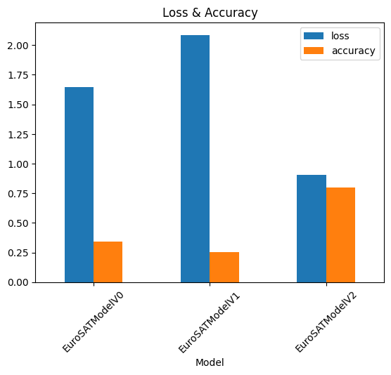

```python
models_comparison[['loss', 'accuracy']].plot.bar(title='Loss & Accuracy')
plt.xlabel('Model')
plt.xticks(rotation=45)
```

Looks like the CNN performs best. But it's not ideal. Let's try to improve it.

# Optimizing the CNN Model

The first thing we could do is add some `nn.Dropout` layers to the two blocks. Their role is to drop a portion of the neurons. Let's set the portion to be 30%:

```python
class EuroSATModelV2a(nn.Module):
    def __init__(self, input_shape: int, hidden_units: int, output_shape: int):
        super().__init__()
        self.conv_block_1 = nn.Sequential(
            nn.Conv2d(in_channels=input_shape, out_channels=hidden_units, kernel_size=3, stride=1, padding=1),
            nn.ReLU(),
            nn.Conv2d(in_channels=hidden_units, out_channels=hidden_units, kernel_size=3, stride=1, padding=1),
            nn.ReLU(),
            nn.MaxPool2d(kernel_size=2),
            nn.Dropout(p=0.3)
        )
        self.conv_block_2 = nn.Sequential(
            nn.Conv2d(in_channels=hidden_units, out_channels=hidden_units, kernel_size=3, stride=1, padding=1),
            nn.ReLU(),
            nn.Conv2d(in_channels=hidden_units, out_channels=hidden_units, kernel_size=3, stride=1, padding=1),
            nn.ReLU(),
            nn.MaxPool2d(kernel_size=2),
            nn.Dropout(p=0.3)
        )
        self.classifier = nn.Sequential(
            nn.Flatten(),
            nn.Linear(in_features=hidden_units * 16 * 16, out_features=output_shape)
        )

    def forward(self, x: torch.Tensor):
        x = self.conv_block_1(x)
        x = self.conv_block_2(x)
        x = self.classifier(x)
        return x
```

Let's instantiate the model:

```python
torch.manual_seed(42)
model2a = EuroSATModelV2a(
    input_shape=3,
    hidden_units=32,
    output_shape=len(classes)
).to(device)

model2a
```

```
EuroSATModelV2a(
  (conv_block_1): Sequential(
    (0): Conv2d(3, 32, kernel_size=(3, 3), stride=(1, 1), padding=(1, 1))
    (1): ReLU()
    (2): Conv2d(32, 32, kernel_size=(3, 3), stride=(1, 1), padding=(1, 1))
    (3): ReLU()
    (4): MaxPool2d(kernel_size=2, stride=2, padding=0, dilation=1, ceil_mode=False)
    (5): Dropout(p=0.3, inplace=False)
  )
  (conv_block_2): Sequential(
    (0): Conv2d(32, 32, kernel_size=(3, 3), stride=(1, 1), padding=(1, 1))
    (1): ReLU()
    (2): Conv2d(32, 32, kernel_size=(3, 3), stride=(1, 1), padding=(1, 1))
    (3): ReLU()
    (4): MaxPool2d(kernel_size=2, stride=2, padding=0, dilation=1, ceil_mode=False)
    (5): Dropout(p=0.3, inplace=False)
  )
  (classifier): Sequential(
    (0): Flatten(start_dim=1, end_dim=-1)
    (1): Linear(in_features=8192, out_features=10, bias=True)
  )
)
```

Let's now define the loss function, optimizer and accuracy:

```python
loss_fn = nn.CrossEntropyLoss()
optimizer = torch.optim.SGD(params=model2a.parameters(), lr=0.02)
accuracy_fn = torchmetrics.Accuracy(task='multiclass', num_classes=len(classes)).to(device)
```

Let's train and evaluate the model:

```python
epochs = 20
for epoch in range(epochs):
    print(f'Epoch: {epoch}\n---------')

    # train
    train_step(model=model2a, data_loader=train_dataloader, loss_fn=loss_fn, optimizer=optimizer, accuracy_fn=accuracy_fn, device=device)
    test_step(model=model2a, data_loader=test_dataloader, loss_fn=loss_fn, accuracy_fn=accuracy_fn, device=device)
```

```
Epoch: 0
---------
Train loss: 1.92495 | Train acc: 0.26181
Test loss: 1.68880 | Test acc: 0.33284
Epoch: 1
---------
Train loss: 1.63997 | Train acc: 0.39977
Test loss: 1.61185 | Test acc: 0.43362
Epoch: 2
---------
Train loss: 1.40260 | Train acc: 0.50014
Test loss: 1.16747 | Test acc: 0.57890
Epoch: 3
---------
Train loss: 1.11090 | Train acc: 0.60968
Test loss: 0.95288 | Test acc: 0.64540
Epoch: 4
---------
Train loss: 0.89898 | Train acc: 0.68093
Test loss: 0.91601 | Test acc: 0.65459
Epoch: 5
---------
Train loss: 0.76764 | Train acc: 0.72440
Test loss: 0.66465 | Test acc: 0.76504
Epoch: 6
---------
Train loss: 0.66887 | Train acc: 0.76380
Test loss: 0.83158 | Test acc: 0.69027
Epoch: 7
---------
Train loss: 0.60047 | Train acc: 0.78477
Test loss: 0.62674 | Test acc: 0.77620
Epoch: 8
---------
Train loss: 0.54571 | Train acc: 0.80671
Test loss: 0.54791 | Test acc: 0.80806
Epoch: 9
---------
Train loss: 0.50021 | Train acc: 0.81880
Test loss: 0.59864 | Test acc: 0.78717
```

[output cut: 25 more lines]

```
---------
Train loss: 0.29895 | Train acc: 0.89444
Test loss: 0.52832 | Test acc: 0.82723
Epoch: 17
---------
Train loss: 0.28797 | Train acc: 0.89662
Test loss: 0.48809 | Test acc: 0.83870
Epoch: 18
---------
Train loss: 0.27637 | Train acc: 0.90218
Test loss: 0.47354 | Test acc: 0.84369
Epoch: 19
---------
Train loss: 0.25855 | Train acc: 0.91000
Test loss: 0.43474 | Test acc: 0.86021
```

```python
model2a_evaluation = evaluate_model(model=model2a, data_loader=test_dataloader, loss_fn=loss_fn, accuracy_fn=accuracy_fn, device=device)
model2a_evaluation
```

```
{'model': 'EuroSATModelV2a',
 'loss': 0.43474334478378296,
 'accuracy': 0.8602071404457092}
```

Let's now compare this model with the previous version:

```python
models_comparison = pd.DataFrame([model2_evaluation, model2a_evaluation]).set_index('model')
models_comparison
```

| model | loss | accuracy |
| --- | --- | --- |
| EuroSATModelV2 | 0.903567 | 0.798200 |
| EuroSATModelV2a | 0.434743 | 0.860207 |

```
(array([0, 1]), [Text(0, 0, 'EuroSATModelV2'), Text(1, 0, 'EuroSATModelV2a')])
```

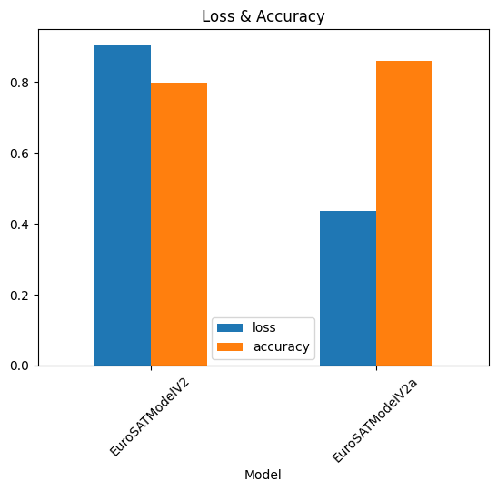

```python
models_comparison[['loss', 'accuracy']].plot.bar(title='Loss & Accuracy')
plt.xlabel('Model')
plt.xticks(rotation=45)
```

We can further optimize the model by adding another `nn.Conv2s` layer to each block:

```python
class EuroSATModelV2b(nn.Module):
    def __init__(self, input_shape: int, hidden_units: int, output_shape: int):
        super().__init__()
        self.conv_block_1 = nn.Sequential(
            nn.Conv2d(in_channels=input_shape, out_channels=hidden_units, kernel_size=3, stride=1, padding=1),
            nn.ReLU(),
            nn.Conv2d(in_channels=hidden_units, out_channels=hidden_units, kernel_size=3, stride=1, padding=1),
            nn.ReLU(),
            nn.Conv2d(in_channels=hidden_units, out_channels=hidden_units, kernel_size=3, stride=1, padding=1),
            nn.ReLU(),
            nn.MaxPool2d(kernel_size=2),
            nn.Dropout(p=0.3)
        )
        self.conv_block_2 = nn.Sequential(
            nn.Conv2d(in_channels=hidden_units, out_channels=hidden_units, kernel_size=3, stride=1, padding=1),
            nn.ReLU(),
            nn.Conv2d(in_channels=hidden_units, out_channels=hidden_units, kernel_size=3, stride=1, padding=1),
            nn.ReLU(),
            nn.Conv2d(in_channels=hidden_units, out_channels=hidden_units, kernel_size=3, stride=1, padding=1),
            nn.ReLU(),
            nn.MaxPool2d(kernel_size=2),
            nn.Dropout(p=0.3)
        )
        self.classifier = nn.Sequential(
            nn.Flatten(),
            nn.Linear(in_features=hidden_units * 16 * 16, out_features=output_shape)
        )

    def forward(self, x: torch.Tensor):
        x = self.conv_block_1(x)
        x = self.conv_block_2(x)
        x = self.classifier(x)
        return x
```

Let's instantiate the model:

```python
torch.manual_seed(42)
model2b = EuroSATModelV2b(
    input_shape=3,
    hidden_units=32,
    output_shape=len(classes)
).to(device)

model2b
```

```
EuroSATModelV2b(
  (conv_block_1): Sequential(
    (0): Conv2d(3, 32, kernel_size=(3, 3), stride=(1, 1), padding=(1, 1))
    (1): ReLU()
    (2): Conv2d(32, 32, kernel_size=(3, 3), stride=(1, 1), padding=(1, 1))
    (3): ReLU()
    (4): Conv2d(32, 32, kernel_size=(3, 3), stride=(1, 1), padding=(1, 1))
    (5): ReLU()
    (6): MaxPool2d(kernel_size=2, stride=2, padding=0, dilation=1, ceil_mode=False)
    (7): Dropout(p=0.3, inplace=False)
  )
  (conv_block_2): Sequential(
    (0): Conv2d(32, 32, kernel_size=(3, 3), stride=(1, 1), padding=(1, 1))
    (1): ReLU()
    (2): Conv2d(32, 32, kernel_size=(3, 3), stride=(1, 1), padding=(1, 1))
    (3): ReLU()
    (4): Conv2d(32, 32, kernel_size=(3, 3), stride=(1, 1), padding=(1, 1))
    (5): ReLU()
    (6): MaxPool2d(kernel_size=2, stride=2, padding=0, dilation=1, ceil_mode=False)
    (7): Dropout(p=0.3, inplace=False)
  )
  (classifier): Sequential(
    (0): Flatten(start_dim=1, end_dim=-1)
    (1): Linear(in_features=8192, out_features=10, bias=True)
  )
)
```

Let's now define the loss function, optimizer and accuracy:

```python
loss_fn = nn.CrossEntropyLoss()
optimizer = torch.optim.SGD(params=model2b.parameters(), lr=0.02)
accuracy_fn = torchmetrics.Accuracy(task='multiclass', num_classes=len(classes)).to(device)
```

Let's train and evaluate the model:

```python
epochs = 20
for epoch in range(epochs):
    print(f'Epoch: {epoch}\n---------')

    # train
    train_step(model=model2b, data_loader=train_dataloader, loss_fn=loss_fn, optimizer=optimizer, accuracy_fn=accuracy_fn, device=device)
    test_step(model=model2b, data_loader=test_dataloader, loss_fn=loss_fn, accuracy_fn=accuracy_fn, device=device)
```

```
Epoch: 0
---------
Train loss: 2.29624 | Train acc: 0.10782
Test loss: 2.29568 | Test acc: 0.11236
Epoch: 1
---------
Train loss: 2.07952 | Train acc: 0.20009
Test loss: 1.76738 | Test acc: 0.29543
Epoch: 2
---------
Train loss: 1.73246 | Train acc: 0.35181
Test loss: 1.62496 | Test acc: 0.39750
Epoch: 3
---------
Train loss: 1.54407 | Train acc: 0.43130
Test loss: 1.40638 | Test acc: 0.48515
Epoch: 4
---------
Train loss: 1.32119 | Train acc: 0.51361
Test loss: 1.21183 | Test acc: 0.55393
Epoch: 5
---------
Train loss: 1.06509 | Train acc: 0.62190
Test loss: 0.90633 | Test acc: 0.67098
Epoch: 6
---------
Train loss: 0.91606 | Train acc: 0.67144
Test loss: 0.83162 | Test acc: 0.70353
Epoch: 7
---------
Train loss: 0.81681 | Train acc: 0.70634
Test loss: 0.69446 | Test acc: 0.75783
Epoch: 8
---------
Train loss: 0.67483 | Train acc: 0.75968
Test loss: 0.61005 | Test acc: 0.78556
Epoch: 9
---------
Train loss: 0.61503 | Train acc: 0.78444
Test loss: 0.69197 | Test acc: 0.75727
```

[output cut: 25 more lines]

```
---------
Train loss: 0.33627 | Train acc: 0.87856
Test loss: 0.55583 | Test acc: 0.81700
Epoch: 17
---------
Train loss: 0.31076 | Train acc: 0.89074
Test loss: 0.62120 | Test acc: 0.80769
Epoch: 18
---------
Train loss: 0.28916 | Train acc: 0.89532
Test loss: 0.53589 | Test acc: 0.83315
Epoch: 19
---------
Train loss: 0.27316 | Train acc: 0.90597
Test loss: 0.47864 | Test acc: 0.84307
```

```python
model2b_evaluation = evaluate_model(model=model2b, data_loader=test_dataloader, loss_fn=loss_fn, accuracy_fn=accuracy_fn, device=device)
model2b_evaluation
```

```
{'model': 'EuroSATModelV2b',
 'loss': 0.4786429703235626,
 'accuracy': 0.8430720567703247}
```

Let's see how the three CNN models compare:

```python
models_comparison = pd.DataFrame([model2_evaluation, model2a_evaluation, model2b_evaluation]).set_index('model')
models_comparison
```

| model | loss | accuracy |
| --- | --- | --- |
| EuroSATModelV2 | 0.903567 | 0.798200 |
| EuroSATModelV2a | 0.434743 | 0.860207 |
| EuroSATModelV2b | 0.478643 | 0.843072 |

```
(array([0, 1, 2]),
 [Text(0, 0, 'EuroSATModelV2'),
```

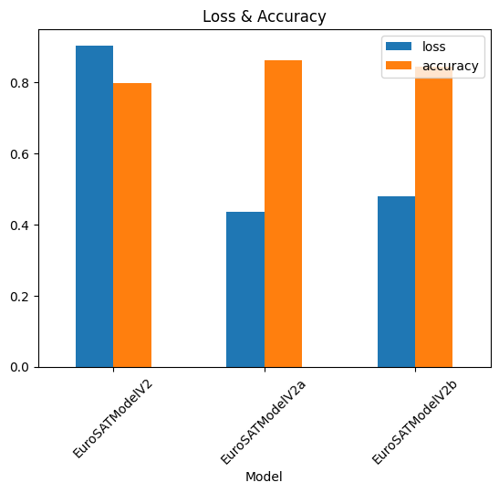

```python
models_comparison[['loss', 'accuracy']].plot.bar(title='Loss & Accuracy')
plt.xlabel('Model')
plt.xticks(rotation=45)
```

Let's add one more improvement. This time, we'll modify the classifier by adding a 50%-`nn.Dropout` layer, an `nn.ReLU` layer and another linear layer:

```python
class EuroSATModelV2c(nn.Module):
    def __init__(self, input_shape: int, hidden_units: int, output_shape: int):
        super().__init__()
        self.conv_block_1 = nn.Sequential(
            nn.Conv2d(in_channels=input_shape, out_channels=hidden_units, kernel_size=3, stride=1, padding=1),
            nn.ReLU(),
            nn.Conv2d(in_channels=hidden_units, out_channels=hidden_units, kernel_size=3, stride=1, padding=1),
            nn.ReLU(),
            nn.Conv2d(in_channels=hidden_units, out_channels=hidden_units, kernel_size=3, stride=1, padding=1),
            nn.ReLU(),
            nn.MaxPool2d(kernel_size=2),
            nn.Dropout(p=0.3)
        )
        self.conv_block_2 = nn.Sequential(
            nn.Conv2d(in_channels=hidden_units, out_channels=hidden_units, kernel_size=3, stride=1, padding=1),
            nn.ReLU(),
            nn.Conv2d(in_channels=hidden_units, out_channels=hidden_units, kernel_size=3, stride=1, padding=1),
            nn.ReLU(),
            nn.Conv2d(in_channels=hidden_units, out_channels=hidden_units, kernel_size=3, stride=1, padding=1),
            nn.ReLU(),
            nn.MaxPool2d(kernel_size=2),
            nn.Dropout(p=0.3)
        )
        self.classifier = nn.Sequential(
            nn.Flatten(),
            nn.Linear(in_features=hidden_units * 16 * 16, out_features=hidden_units * 16 * 16),
            nn.ReLU(),
            nn.Dropout(0.5),
            nn.Linear(in_features=hidden_units * 16 * 16, out_features=output_shape)
        )

    def forward(self, x: torch.Tensor):
        x = self.conv_block_1(x)
        x = self.conv_block_2(x)
        x = self.classifier(x)
        return x
```

Let's instantiate the model:

```python
torch.manual_seed(42)
model2c = EuroSATModelV2c(
    input_shape=3,
    hidden_units=32,
    output_shape=len(classes)
).to(device)

model2c
```

```
EuroSATModelV2c(
  (conv_block_1): Sequential(
    (0): Conv2d(3, 32, kernel_size=(3, 3), stride=(1, 1), padding=(1, 1))
    (1): ReLU()
    (2): Conv2d(32, 32, kernel_size=(3, 3), stride=(1, 1), padding=(1, 1))
    (3): ReLU()
    (4): Conv2d(32, 32, kernel_size=(3, 3), stride=(1, 1), padding=(1, 1))
    (5): ReLU()
    (6): MaxPool2d(kernel_size=2, stride=2, padding=0, dilation=1, ceil_mode=False)
    (7): Dropout(p=0.3, inplace=False)
  )
  (conv_block_2): Sequential(
    (0): Conv2d(32, 32, kernel_size=(3, 3), stride=(1, 1), padding=(1, 1))
    (1): ReLU()
    (2): Conv2d(32, 32, kernel_size=(3, 3), stride=(1, 1), padding=(1, 1))
    (3): ReLU()
    (4): Conv2d(32, 32, kernel_size=(3, 3), stride=(1, 1), padding=(1, 1))
    (5): ReLU()
    (6): MaxPool2d(kernel_size=2, stride=2, padding=0, dilation=1, ceil_mode=False)
    (7): Dropout(p=0.3, inplace=False)
  )
  (classifier): Sequential(
    (0): Flatten(start_dim=1, end_dim=-1)
    (1): Linear(in_features=8192, out_features=8192, bias=True)
    (2): ReLU()
    (3): Dropout(p=0.5, inplace=False)
    (4): Linear(in_features=8192, out_features=10, bias=True)
  )
)
```

Let's define the loss function, optimizer and accuracy:

```python
loss_fn = nn.CrossEntropyLoss()
optimizer = torch.optim.SGD(params=model2c.parameters(), lr=0.02)
accuracy_fn = torchmetrics.Accuracy(task='multiclass', num_classes=len(classes)).to(device)
```

Let's train and evaluate the model:

```python
epochs = 20
for epoch in range(epochs):
    print(f'Epoch: {epoch}\n---------')

    # train
    train_step(model=model2c, data_loader=train_dataloader, loss_fn=loss_fn, optimizer=optimizer, accuracy_fn=accuracy_fn, device=device)
    test_step(model=model2c, data_loader=test_dataloader, loss_fn=loss_fn, accuracy_fn=accuracy_fn, device=device)
```

```
Epoch: 0
---------
Train loss: 2.29606 | Train acc: 0.11208
Test loss: 2.29577 | Test acc: 0.11236
Epoch: 1
---------
Train loss: 2.29500 | Train acc: 0.11403
Test loss: 2.29531 | Test acc: 0.11144
Epoch: 2
---------
Train loss: 2.13820 | Train acc: 0.18023
Test loss: 1.79248 | Test acc: 0.30350
Epoch: 3
---------
Train loss: 1.72966 | Train acc: 0.33032
Test loss: 1.59057 | Test acc: 0.37555
Epoch: 4
---------
Train loss: 1.58228 | Train acc: 0.38926
Test loss: 1.53846 | Test acc: 0.40736
Epoch: 5
---------
Train loss: 1.36793 | Train acc: 0.49431
Test loss: 1.18499 | Test acc: 0.58752
Epoch: 6
---------
Train loss: 1.15396 | Train acc: 0.57088
Test loss: 1.03731 | Test acc: 0.62229
Epoch: 7
---------
Train loss: 0.98389 | Train acc: 0.64255
Test loss: 0.92103 | Test acc: 0.66926
Epoch: 8
---------
Train loss: 0.87593 | Train acc: 0.68157
Test loss: 0.80237 | Test acc: 0.71105
Epoch: 9
---------
Train loss: 0.79426 | Train acc: 0.71417
Test loss: 0.79490 | Test acc: 0.70963
```

[output cut: 25 more lines]

```
---------
Train loss: 0.30994 | Train acc: 0.89287
Test loss: 0.49068 | Test acc: 0.82594
Epoch: 17
---------
Train loss: 0.27412 | Train acc: 0.90634
Test loss: 0.52953 | Test acc: 0.82427
Epoch: 18
---------
Train loss: 0.22980 | Train acc: 0.92069
Test loss: 0.55975 | Test acc: 0.81207
Epoch: 19
---------
Train loss: 0.19639 | Train acc: 0.93153
Test loss: 0.68178 | Test acc: 0.80369
```

```python
model2c_evaluation = evaluate_model(model=model2c, data_loader=test_dataloader, loss_fn=loss_fn, accuracy_fn=accuracy_fn, device=device)
model2c_evaluation
```

```
{'model': 'EuroSATModelV2c',
 'loss': 0.68178391456604,
 'accuracy': 0.8036859631538391}
```

Let's compare all the CNN models:

```python
models_comparison = pd.DataFrame([model2_evaluation, model2a_evaluation, model2b_evaluation, model2c_evaluation]).set_index('model')
models_comparison
```

| model | loss | accuracy |
| --- | --- | --- |
| EuroSATModelV2 | 0.903567 | 0.798200 |
| EuroSATModelV2a | 0.434743 | 0.860207 |
| EuroSATModelV2b | 0.478643 | 0.843072 |
| EuroSATModelV2c | 0.681784 | 0.803686 |

```
(array([0, 1, 2, 3]),
 [Text(0, 0, 'EuroSATModelV2'),
```

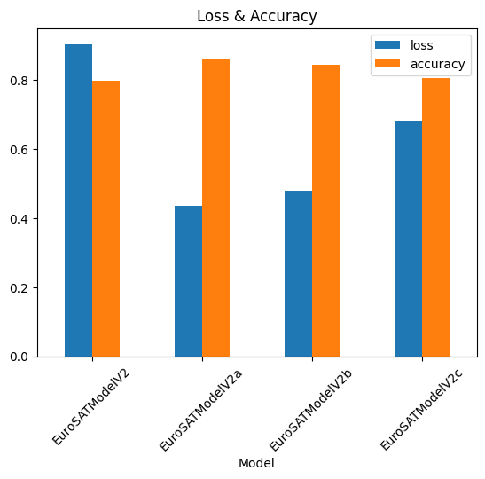

```python
models_comparison[['loss', 'accuracy']].plot.bar(title='Loss & Accuracy')
plt.xlabel('Model')
plt.xticks(rotation=45)
```

We could keep optimizing the model by changing the learning rate, changing the number of epochs, changing the number of hidden units, adding more layers to the blocks and classifier, and so on. But let's stop here.

Looks like of all four CNN models, `model2a` is the best. So, let's use it to make some predictions.

# Predictions

Let's use the best model to make some predictions:

```python
def make_predictions(model: nn.Module, data: list, device: torch.device):
    pred_probs = []
    model.eval()
    with torch.inference_mode():
        for sample in data:
            sample = torch.unsqueeze(sample, dim=0).to(device)

            # logits
            pred_logit = model(sample)

            # logits -> prediction probabilities
            pred_prob = torch.softmax(pred_logit.squeeze(), dim=0)

            pred_probs.append(pred_prob.cpu())
    return torch.stack(pred_probs)
```

Let's get some random samples:

```python
import random
random.seed(42)
test_samples = []
test_labels = []
for sample, label in random.sample(list(test_data), k=16):
    test_samples.append(sample)
    test_labels.append(label)
```

Let's use the samples for predictions:

```python
pred_probs = make_predictions(model=model2a, data=test_samples, device=device)
pred_probs
```

```
tensor([[5.2620e-05, 9.9973e-01, 8.0184e-05, 8.9340e-05, 4.5576e-12, 5.4281e-07,
         1.4791e-08, 1.3254e-10, 1.7600e-05, 3.0821e-05],
        [4.2757e-05, 1.0373e-06, 1.6362e-01, 4.9032e-01, 2.6546e-05, 5.4002e-03,
         3.3794e-01, 3.2598e-04, 2.3233e-03, 1.0836e-07],
        [4.3061e-05, 1.4522e-01, 8.5304e-01, 1.1201e-04, 1.1554e-08, 9.6508e-04,
         5.5737e-04, 6.5630e-07, 6.4802e-05, 3.3018e-06],
        [1.6674e-04, 2.3102e-13, 1.1174e-09, 1.0854e-02, 1.7073e-08, 1.2278e-07,
         5.0648e-05, 3.9191e-11, 9.8893e-01, 3.0446e-13],
        [1.4487e-05, 9.9870e-01, 1.9194e-04, 2.6715e-05, 4.0150e-11, 1.7323e-06,
         1.4556e-08, 2.3499e-10, 1.0334e-03, 3.5787e-05],
        [4.9741e-15, 5.1709e-13, 1.5151e-04, 6.1187e-06, 9.9942e-01, 2.9146e-10,
         4.1278e-07, 4.2279e-04, 1.4350e-09, 4.1282e-11],
        [6.9446e-07, 4.4732e-05, 9.9278e-01, 6.5584e-05, 1.6141e-07, 5.1006e-04,
         6.4587e-03, 1.3020e-04, 1.3990e-05, 4.0530e-08],
        [1.0597e-02, 2.6723e-04, 6.1078e-10, 4.6423e-04, 7.6807e-12, 9.7655e-01,
         6.7932e-07, 5.9719e-11, 1.1939e-02, 1.8512e-04],
        [1.9481e-04, 8.2576e-08, 1.2252e-01, 1.8858e-02, 3.1774e-07, 5.6317e-05,
         7.5772e-04, 1.9258e-08, 8.5761e-01, 9.9261e-09],
        [3.4365e-02, 1.9095e-06, 6.8999e-05, 6.5470e-01, 1.2693e-08, 8.7312e-04,
         1.5308e-01, 2.4636e-09, 1.5691e-01, 4.7072e-07],
        [9.7083e-01, 9.8780e-08, 2.8806e-03, 9.6759e-03, 1.2170e-07, 3.8617e-05,
         1.6546e-02, 7.3366e-10, 3.3181e-05, 5.7991e-08],
        [3.1431e-02, 1.1575e-02, 2.5030e-05, 9.6184e-02, 3.7493e-08, 8.2887e-01,
         8.4270e-04, 1.4772e-07, 3.1071e-02, 2.1957e-06],
        [3.4066e-03, 6.3285e-02, 8.0721e-05, 4.5271e-02, 6.3864e-08, 7.9327e-01,
         1.3115e-02, 3.9299e-06, 8.1521e-02, 4.6054e-05],
        [1.2153e-11, 7.4877e-13, 1.4819e-06, 1.9659e-06, 9.9999e-01, 3.4144e-08,
         7.7698e-07, 3.5343e-07, 5.2866e-07, 9.9078e-11],
        [6.9118e-01, 6.6048e-04, 1.8911e-02, 2.4607e-03, 2.5089e-07, 1.0543e-01,
         1.5094e-01, 3.8922e-09, 2.8508e-02, 1.9163e-03],
        [4.7205e-05, 9.9980e-01, 2.4397e-05, 5.7754e-05, 1.5298e-11, 8.7736e-07,
         6.7762e-09, 4.1086e-10, 5.2881e-05, 1.9618e-05]])
```

Here we have prediction probabilities, but we need prediction labels. Let's turn the former into the latter then:

```python
pred_labels = torch.argmax(pred_probs, dim=1)
pred_labels
```

```
tensor([1, 3, 2, 8, 1, 4, 2, 5, 8, 3, 0, 5, 5, 4, 0, 1])
```

Let's check out the test labels. The more similar they are the better:

```python
test_labels
```

```
[1, 6, 2, 8, 1, 4, 2, 5, 8, 8, 0, 5, 5, 4, 0, 1]
```

Let's visualize the samples and predictions and see how many of them were correct:

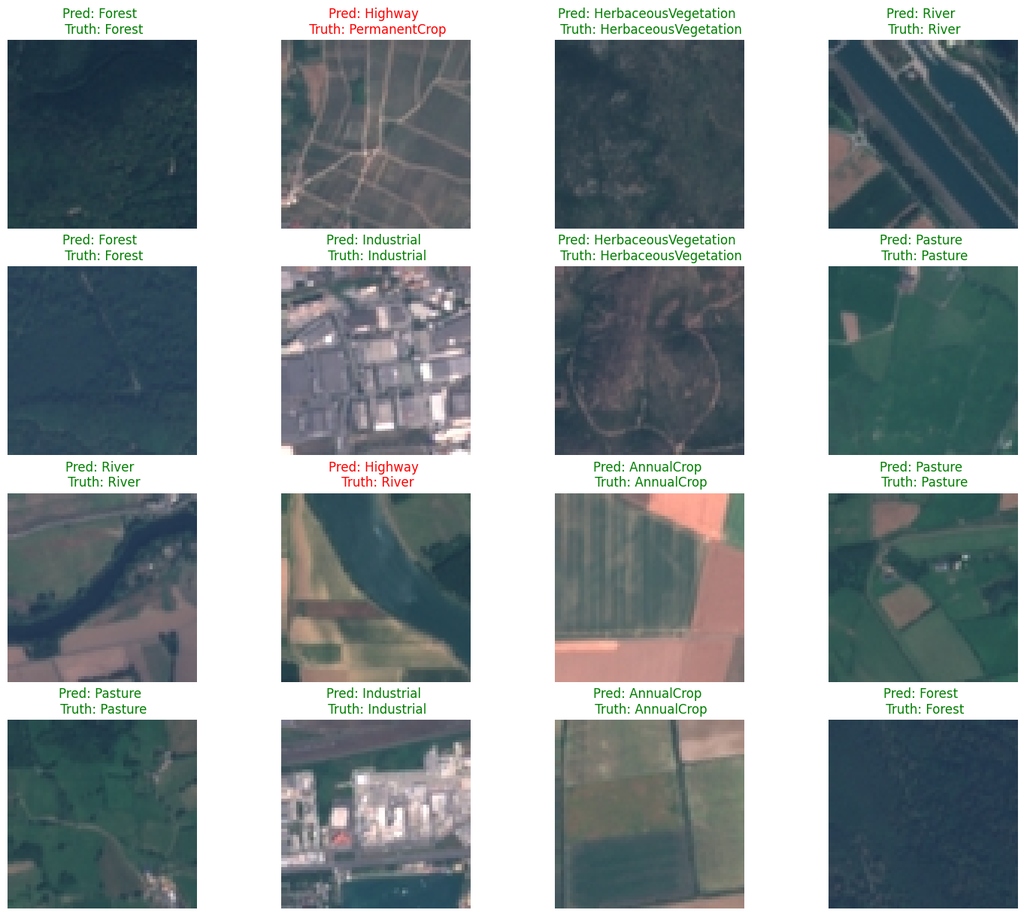

```python
plt.figure(figsize=(18, 15))
for i, sample in enumerate(test_samples):

    # create subplot
    plt.subplot(4, 4, i + 1)

    # plot target image
    plt.imshow(sample.permute(1, 2, 0))

    # prediction label
    pred_label = classes[pred_labels[i]]

    # ground truth label
    gt_label = classes[test_labels[i]]

    # title text
    title_text = f'Pred: {pred_label} \n Truth: {gt_label}'

    # title color
    title_color = 'g' if pred_label == gt_label else 'r'

    # plot title
    plt.title(title_text, color=title_color)
    plt.axis(False)
```

As we can see, the predictions were not ideal, but most of them were correct.